# R Notebook

```r
suppressPackageStartupMessages(library("ggplot2"))
theme_set(ggpubr::theme_pubr(base_size=10, legend='bottom'))
```

```r
suppressPackageStartupMessages(library("DESeq2"))
```

#Note that we do not have Clark Scores or MIA scores for AVAST-M lymph node samples and these need to be commented out to avoid errors.

```r
#Load the data
tissue<-c("Skin")
load(paste("~/Desktop/Melanoma/deseq2Results/tc",tissue,"EventMetNo_VS_tc",tissue,"EventMetYes_CovariateCorrection.deseq2/de.Rdata", sep=""))
#expressionData <- data.frame(assay(vsd))
#write.table(expressionData, "~/Desktop/Melanoma/AVAST-M_Skin-Primaries_VST_normalized_expression_data.csv", sep = ",", quote = F, row.names = T, col.names = T)
```

```r
#expressionData <- data.frame(assay(vsd))
#write.table(data.f, "~/Desktop/Melanoma/AVAST-M_Regional-Lymph-Node_raw_expression_data.csv", sep = ",", quote = F, row.names = T, col.names = T)
```

```r
#find ENSEMBL ID corresponding to GRAMD1B
geneName<-"GRAMD1B"
select<-as.character(res.annot$id[res.annot$Name==geneName])
#extract expression of this gene
expressionData <- data.frame(assay(vsd)[select, ])
#Replace ENSEMBL IDs with corresponding gene names
names(expressionData) <- geneName
stand.fun <- function(x){(x-mean(x,na.rm=TRUE))/sd(x,na.rm=TRUE)}
stdSignature<-stand.fun(expressionData$GRAMD1B)
names(stdSignature)<-rownames(expressionData) #make sure they retain the name of the samples
```

```r
#Multiply by beta coefficient?
#betaCoeff <- read.table("~/Desktop/Melanoma/betaCoeff.tsv", sep = "\t", header = TRUE, quote = "")
#extract beta coefficient for the gene of interest
#betaCoeffGene <- betaCoeff[select, "EventMet_Yes_vs_No"]
#weightedSignature <- expressionData*betaCoeffGene
#standardization of the weighted signature
#stand.fun <- function(x){(x-mean(x,na.rm=TRUE))/sd(x,na.rm=TRUE)}
#stdWeightedSignature <- stand.fun(weightedSignature$GRAMD1B)
#names(stdWeightedSignature)<-rownames(weightedSignature) #make sure they retain the name of the samples
```

As expected the absolute values after standardization of weighted signature (stand.fun(weightedSignature$GRAMD1B)) is same as those of standardized expression values (stand.fun(expressionData$GRAMD1B)). The only difference comes from sign of the beta coefficient which is negative for GRAMD1B

```r
#Load clinical data
clinicalData<-data.frame(colData(vsd))
clinicalData$Signature<- stdSignature[rownames(clinicalData)] #merge signature in clinical data frame
```

```r
#Divide in high/low groups based on mean value
co_mean<-mean(clinicalData$Signature)
clinicalData$SignatureGroupMean <- as.factor(ifelse(clinicalData$Signature >= as.numeric(co_mean), "High", "Low"))

#co_median<-median(clinicalData$Signature)
#clinicalData$SignatureGroupMedian <- as.factor(ifelse(clinicalData$Signature >= as.numeric(co_median), "High", "Low"))
```

## Repeat for PTEN information and calculate high/low groups based on mean value

```r
#vstNormalizedExpressionData = assay(vsd)
geneName<-"PTEN"
select<-"ENSG00000171862"
#extract expression of this gene
expressionData <- data.frame(assay(vsd)[select, ])
#Replace ENSEMBL IDs with corresponding gene names
names(expressionData) <- geneName
stand.fun <- function(x){(x-mean(x,na.rm=TRUE))/sd(x,na.rm=TRUE)}
stdSignature<-stand.fun(expressionData$PTEN)
names(stdSignature)<-rownames(expressionData) #make sure they retain the name of the samples
clinicalData$PTEN<- stdSignature[rownames(clinicalData)] #merge signature in clinical data frame
```

```r
#Divide in high/low groups based on mean value
co_mean<-mean(clinicalData$PTEN)
clinicalData$PTENGroupMean <- as.factor(ifelse(clinicalData$PTEN >= as.numeric(co_mean), "High", "Low"))
```

#Check association of GRAMD1B with relapse

```r
my_comparisons <- list( c("Yes", "No"))
ggplot(clinicalData[!is.na(clinicalData$EventMet),], aes(x=EventMet, y=Signature))+
  geom_violin()+
  geom_jitter(height = 0, width = 0.1, alpha = 0.5, aes())+
  #scale_fill_brewer(type="qual", palette = "Dark2", name = "GRAMD1B risk group")+
  xlab("Distant metastases (AVAST-M Skin)")+
  ylab("VST normalized GRAMD1B expression (stand.)")+
  #geom_hline(yintercept = quantile(clinicalData$Signature, 0.75), color = "grey", linetype = "longdash")+
  theme(text=element_text(size=7,  family="sans"))+
  ggpubr::stat_compare_means(comparisons = my_comparisons, method = "t.test", size = 2.5, family="sans")#+ # Add pairwise comparisons p-value
  #ggpubr::stat_compare_means(label.y = 6, method = "anova", size = 2.5, family="sans")#+
```

Find suitable cut-off. After talking to Roy, it seems that we could go for a weighted GRAMD1B value of 0? Let’s check the median value. May be I can take the median cut-off and perform chi-squared test to check if there is no difference between the mean of 2 groups?

```r
#Divide in high/low groups based on mean and median
#co_mean<-mean(clinicalData$Signature)
co_median<-median(clinicalData$Signature)
co_0_33<-quantile(clinicalData$Signature, 0.33)
co_0_66<-quantile(clinicalData$Signature, 0.66)
if (tissue=="Skin") {
  co_density_intersection<--0.223156179#0.235202939
}else{
  co_density_intersection<-0.3481057115#-0.223156179#0.235202939
}
suppressPackageStartupMessages(library(plotly))
p<-ggplot(data = clinicalData, aes(x = Signature, fill=EventMet)) +
  geom_density(alpha=0.3)+
  geom_vline(xintercept=c(co_mean, co_median, co_0_33, co_0_66, co_density_intersection), linetype=c('twodash', 'longdash', 'dotted', 'dotdash', 'dashed'))+
  ggtitle(tissue)
ggplotly(p)
```

```r
#clinicalData$SignatureGroupMean <- as.factor(ifelse(clinicalData$Signature >= as.numeric(co_mean), "High", "Low"))
clinicalData$SignatureGroupMedian <- as.factor(ifelse(clinicalData$Signature >= as.numeric(co_median), "High", "Low"))
clinicalData$SignatureGroup0_33 <- as.factor(ifelse(clinicalData$Signature >= as.numeric(co_0_33), "High", "Low"))
clinicalData$SignatureGroup0_66 <- as.factor(ifelse(clinicalData$Signature >= as.numeric(co_0_66), "High", "Low"))
clinicalData$SignatureGroupDensityIntersection <- as.factor(ifelse(clinicalData$Signature >= as.numeric(co_density_intersection), "High", "Low"))

print(chisq.test(clinicalData$SignatureGroupMean, clinicalData$EventMet))
print(chisq.test(clinicalData$SignatureGroupMedian, clinicalData$EventMet))
print(chisq.test(clinicalData$SignatureGroup0_33, clinicalData$EventMet))
print(chisq.test(clinicalData$SignatureGroup0_66, clinicalData$EventMet))
print(chisq.test(clinicalData$SignatureGroupDensityIntersection, clinicalData$EventMet))
```

#Check association of NRAS with other clinical covariates

```r
print(chisq.test(clinicalData$NRAS, clinicalData$EventMet))
print(chisq.test(clinicalData$NRAS, clinicalData$Bres))
print(chisq.test(clinicalData$NRAS, clinicalData$Ulc))
```

#Check association of GRAMD1B with ulceration

```r
my_comparisons <- list( c("Present", "Absent"))
ggplot(clinicalData[!is.na(clinicalData$Ulc),], aes(x=Ulc, y=Signature))+
  geom_violin()+
  geom_jitter(height = 0, width = 0.1, alpha = 0.5, aes())+
  #scale_fill_brewer(type="qual", palette = "Dark2", name = "GRAMD1B risk group")+
  xlab("Ulc (AVAST-M Skin)")+
  ylab("VST normalized GRAMD1B expression (stand.)")+
  #geom_hline(yintercept = quantile(clinicalData$Signature, 0.75), color = "grey", linetype = "longdash")+
  theme(text=element_text(size=7,  family="sans"))+
  ggpubr::stat_compare_means(comparisons = my_comparisons, method = "t.test", size = 2.5, family="sans")#+ # Add pairwise comparisons p-value
  #ggpubr::stat_compare_means(label.y = 6, method = "anova", size = 2.5, family="sans")#+
```

#Check association of GRAMD1B with Bres

```r
my_comparisons <- list( c("<= 2.0 mm", ">2-4mm"), c("<= 2.0 mm", ">4.0mm"), c(">2-4mm", ">4.0mm"))
ggplot(clinicalData[!is.na(clinicalData$Bres),], aes(x=Bres, y=Signature))+
  geom_violin()+
  geom_jitter(height = 0, width = 0.1, alpha = 0.5, aes())+
  #scale_fill_brewer(type="qual", palette = "Dark2", name = "GRAMD1B risk group")+
  xlab("Bres (AVAST-M Skin)")+
  ylab("VST normalized GRAMD1B expression (stand.)")+
  #geom_hline(yintercept = quantile(clinicalData$Signature, 0.75), color = "grey", linetype = "longdash")+
  theme(text=element_text(size=7,  family="sans"))+
  ggpubr::stat_compare_means(comparisons = my_comparisons, method = "t.test", size = 2.5, family="sans")+ # Add pairwise comparisons p-value
  ggpubr::stat_compare_means(label.y = 6, method = "anova", size = 2.5, family="sans")#+
```

#Check association of GRAMD1B with Stage

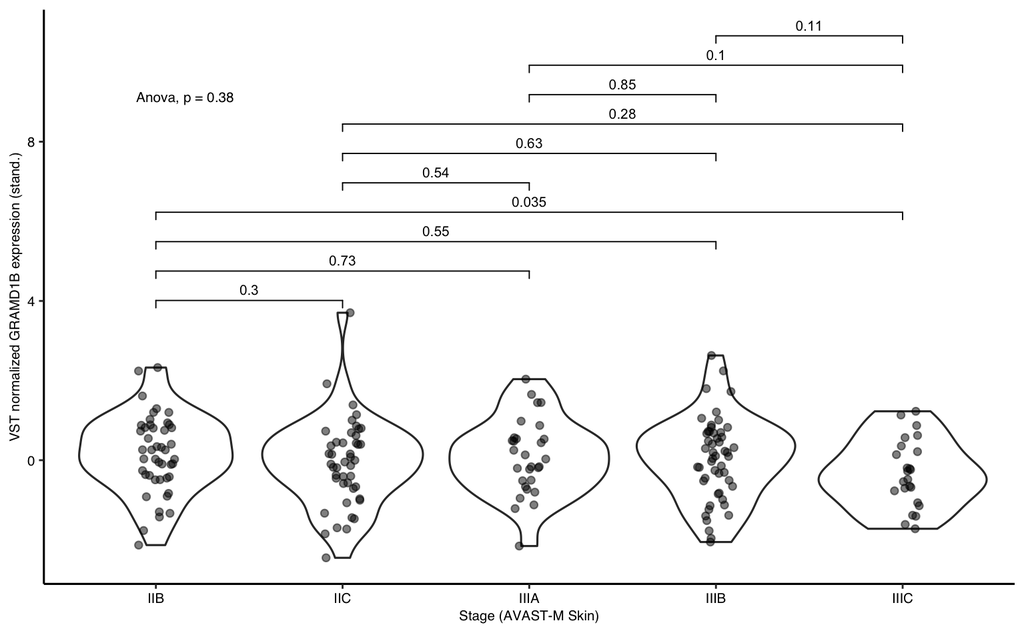

```r
my_comparisons <- list( c("IIB", "IIC"), c("IIB", "IIIA"), c("IIB", "IIIB"), c("IIB", "IIIC"),
                        c("IIC", "IIIA"), c("IIC", "IIIB"), c("IIC", "IIIC"),
                        c("IIIA", "IIIB"), c("IIIA", "IIIC"),
                        c("IIIB", "IIIC"))
ggplot(clinicalData[!is.na(clinicalData$Stage),], aes(x=Stage, y=Signature))+
  geom_violin()+
  geom_jitter(height = 0, width = 0.1, alpha = 0.5, aes())+
  #scale_fill_brewer(type="qual", palette = "Dark2", name = "GRAMD1B risk group")+
  xlab("Stage (AVAST-M Skin)")+
  ylab("VST normalized GRAMD1B expression (stand.)")+
  #geom_hline(yintercept = quantile(clinicalData$Signature, 0.75), color = "grey", linetype = "longdash")+
  theme(text=element_text(size=7,  family="sans"))+
  ggpubr::stat_compare_means(comparisons = my_comparisons, method = "t.test", size = 2.5, family="sans")+ # Add pairwise comparisons p-value
  ggpubr::stat_compare_means(label.y = 9, method = "anova", size = 2.5, family="sans")#+
ggsave(paste("../results/AVAST-M_primaries_Stage_substages.pdf", sep=""), device = "pdf", width =8, units = "cm", height=6)
```

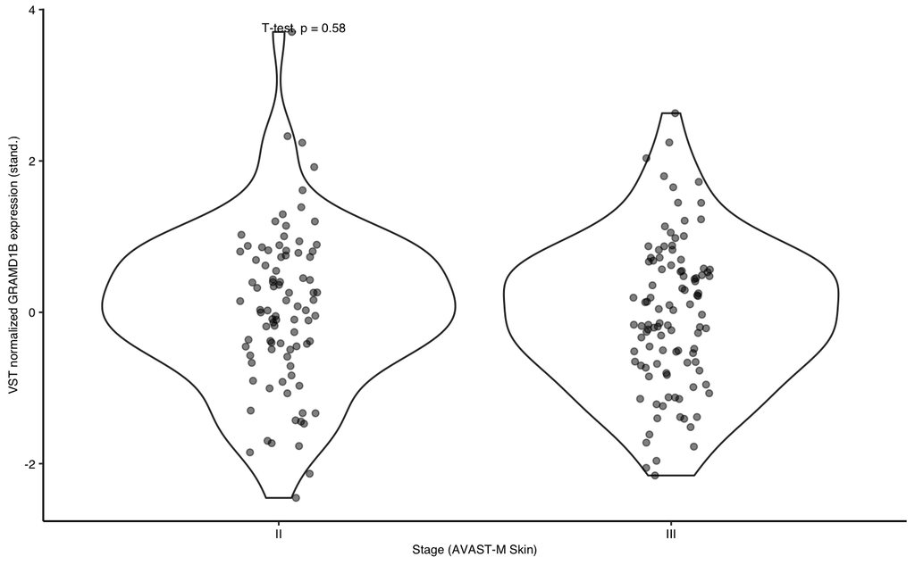

```r
ggplot(clinicalData[!is.na(clinicalData$Stage_binary),], aes(x=Stage_binary, y=Signature))+
  geom_violin()+
  geom_jitter(height = 0, width = 0.1, alpha = 0.5, aes())+
  #scale_fill_brewer(type="qual", palette = "Dark2", name = "GRAMD1B risk group")+
  xlab("Stage (AVAST-M Skin)")+
  ylab("VST normalized GRAMD1B expression (stand.)")+
  #geom_hline(yintercept = quantile(clinicalData$Signature, 0.75), color = "grey", linetype = "longdash")+
  theme(text=element_text(size=7,  family="sans"))+
  ggpubr::stat_compare_means(method = "t.test", size = 2.5, family="sans")#+ # Add pairwise comparisons p-value
  #ggpubr::stat_compare_means(label.y = 9, method = "anova", size = 2.5, family="sans")
ggsave(paste("../results/AVAST-M_primaries_Stage_binary.pdf", sep=""), device = "pdf", width =8, units = "cm", height=6)
```

#Check association of GRAMD1B with Site

```r
my_comparisons <- list( c("Head and neck", "Lower lims"), c("Head and neck", "Trunk"), c("Head and neck", "Upper limbs"),
                        c("Lower lims", "Trunk"), c("Lower lims", "Upper limbs"),
                        c("Trunk", "Upper limbs"))
ggplot(clinicalData[!is.na(clinicalData$Site),], aes(x=Site, y=Signature))+
  geom_violin()+
  geom_jitter(height = 0, width = 0.1, alpha = 0.5, aes())+
  #scale_fill_brewer(type="qual", palette = "Dark2", name = "GRAMD1B risk group")+
  xlab("Site (AVAST-M Skin)")+
  ylab("VST normalized GRAMD1B expression (stand.)")+
  #geom_hline(yintercept = quantile(clinicalData$Signature, 0.75), color = "grey", linetype = "longdash")+
  theme(text=element_text(size=7,  family="sans"))+
  ggpubr::stat_compare_means(comparisons = my_comparisons, method = "t.test", size = 2.5, family="sans")+ # Add pairwise comparisons p-value
  ggpubr::stat_compare_means(label.y = 9, method = "anova", size = 2.5, family="sans")#+
```

#Check association of GRAMD1B with BRAF mutation

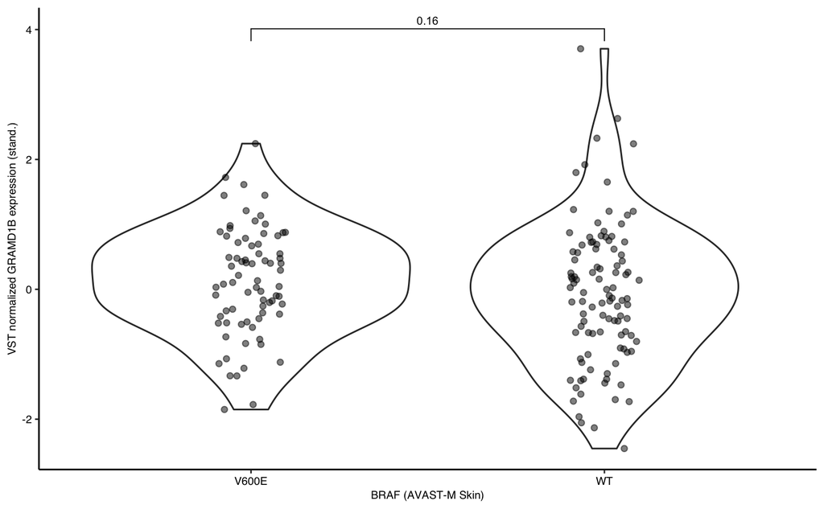

```r
my_comparisons <- list( c("V600E", "WT"))
ggplot(clinicalData[!is.na(clinicalData$BRAF),], aes(x=BRAF, y=Signature))+
  geom_violin()+
  geom_jitter(height = 0, width = 0.1, alpha = 0.5, aes())+
  #scale_fill_brewer(type="qual", palette = "Dark2", name = "GRAMD1B risk group")+
  xlab("BRAF (AVAST-M Skin)")+
  ylab("VST normalized GRAMD1B expression (stand.)")+
  #geom_hline(yintercept = quantile(clinicalData$Signature, 0.75), color = "grey", linetype = "longdash")+
  theme(text=element_text(size=7,  family="sans"))+
  ggpubr::stat_compare_means(comparisons = my_comparisons, method = "t.test", size = 2.5, family="sans")
ggsave(paste("../results/AVAST-M_primaries_BRAF.pdf", sep=""), device = "pdf", width =8, units = "cm", height=6)
```

```r
#+ # Add pairwise comparisons p-value
  #ggpubr::stat_compare_means(label.y = 9, method = "anova", size = 2.5, family="sans")#+
```

#Check association of GRAMD1B with NRAS mutation

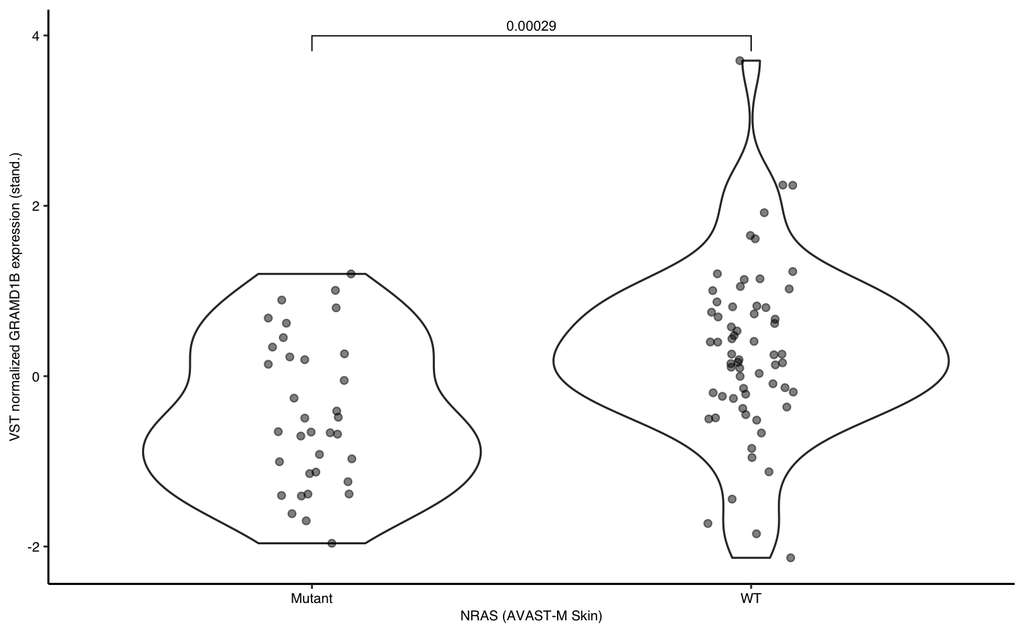

```r
my_comparisons <- list( c("Mutant", "WT"))
ggplot(clinicalData[!is.na(clinicalData$NRAS),], aes(x=NRAS, y=Signature))+
  geom_violin()+
  geom_jitter(height = 0, width = 0.1, alpha = 0.5, aes())+
  #scale_fill_brewer(type="qual", palette = "Dark2", name = "GRAMD1B risk group")+
  xlab("NRAS (AVAST-M Skin)")+
  ylab("VST normalized GRAMD1B expression (stand.)")+
  #geom_hline(yintercept = quantile(clinicalData$Signature, 0.75), color = "grey", linetype = "longdash")+
  theme(text=element_text(size=7,  family="sans"))+
  ggpubr::stat_compare_means(comparisons = my_comparisons, method = "t.test", size = 2.5, family="sans")
ggsave(paste("../results/AVAST-M_primaries_NRAS.pdf", sep=""), device = "pdf", width =8, units = "cm", height=6)
```

```r
#+ # Add pairwise comparisons p-value
  #ggpubr::stat_compare_means(label.y = 9, method = "anova", size = 2.5, family="sans")#+
```

#With PTEN

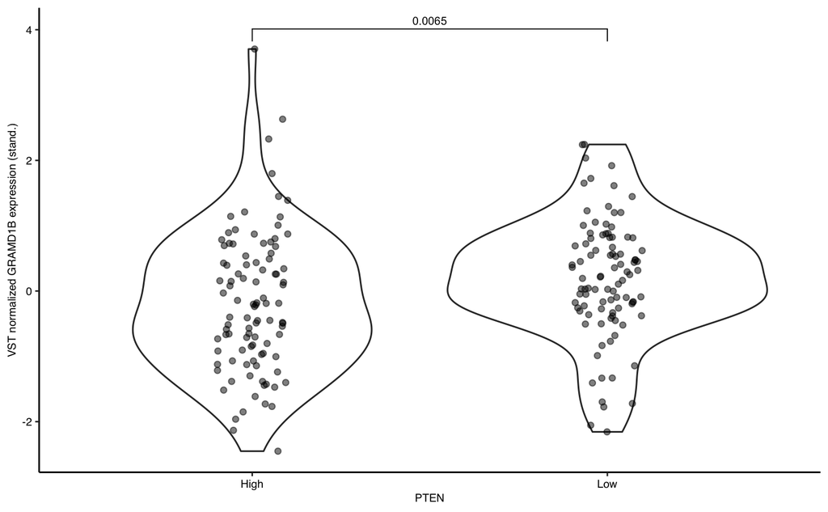

```r
clinicalData$PTENGroupMean<-factor(clinicalData$PTENGroupMean)
#levels(clinicalData$BRAF)<-c("WT", "Mutant")
my_comparisons <- list( c("High", "Low"))
ggplot(clinicalData[!is.na(clinicalData$PTENGroupMean),], aes(x=PTENGroupMean, y=Signature))+
  geom_violin()+
  geom_jitter(height = 0, width = 0.1, alpha = 0.5, aes())+
  #scale_fill_brewer(type="qual", palette = "Dark2", name = "GRAMD1B risk group")+
  xlab("PTEN")+
  ylab("VST normalized GRAMD1B expression (stand.)")+
  #geom_hline(yintercept = quantile(clinicalData$Signature, 0.75), color = "grey", linetype = "longdash")+
  theme(text=element_text(size=7,  family="sans"))+
  ggpubr::stat_compare_means(comparisons = my_comparisons, method = "t.test", size = 2.5, family="sans")
ggsave(paste("../results/AVAST-M_primaries_PTEN.pdf", sep=""), device = "pdf", width =8, units = "cm", height=6)
```

#With BRAS mutant PTEN low

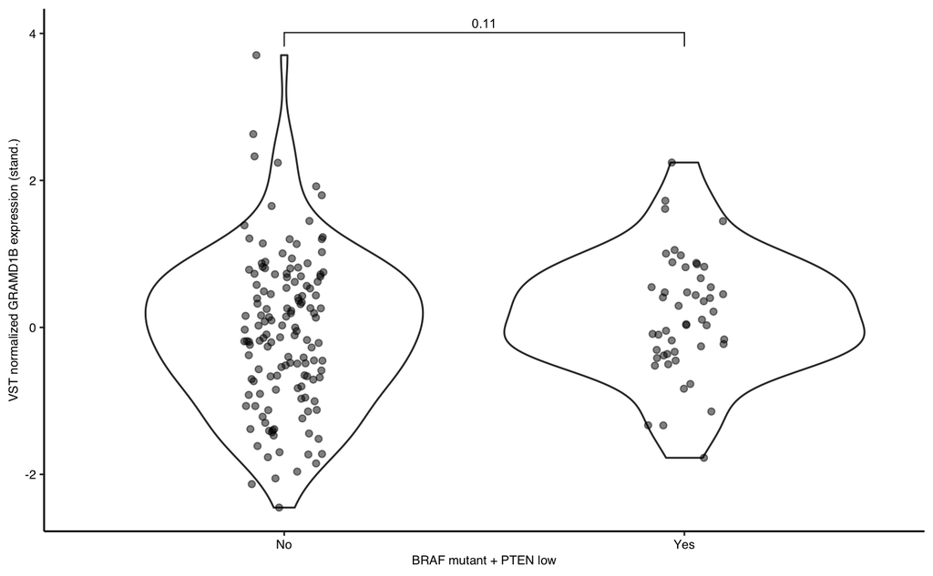

```r
clinicalData$BRAF_PTEN<-ifelse(
   (clinicalData$BRAF=="V600E") & (clinicalData$PTENGroupMean=="Low"),
   "Yes",
   "No")
clinicalData$BRAF_PTEN<-factor(clinicalData$BRAF_PTEN)
my_comparisons <- list( c("Yes", "No"))
ggplot(clinicalData[!is.na(clinicalData$BRAF_PTEN),], aes(x=BRAF_PTEN, y=Signature))+
  geom_violin()+
  geom_jitter(height = 0, width = 0.1, alpha = 0.5, aes())+
  #scale_fill_brewer(type="qual", palette = "Dark2", name = "GRAMD1B risk group")+
  xlab("BRAF mutant + PTEN low")+
  ylab("VST normalized GRAMD1B expression (stand.)")+
  #geom_hline(yintercept = quantile(clinicalData$Signature, 0.75), color = "grey", linetype = "longdash")+
  theme(text=element_text(size=7,  family="sans"))+
  ggpubr::stat_compare_means(comparisons = my_comparisons, method = "t.test", size = 2.5, family="sans")
ggsave(paste("../results/AVAST-M_primaries_BRAF_PTEN.pdf", sep=""), device = "pdf", width =8, units = "cm", height=6)
```

#Check association of GRAMD1B with TIL counts

```r
jt_ns_sm_scores = read.table("../../../JT_NS_SM_Combined.xls - JT_NS_SM.tsv", sep = "\t", header = TRUE, quote = "")
combinedScore <- data.frame("Scanned_file.me"= jt_ns_sm_scores$JT_Scanned_file.me,
                                "R.Seq_sampleID"= jt_ns_sm_scores$JT_R.Seq_sampleID,
                                "ClarkScore"= ifelse(jt_ns_sm_scores$JT_Clark_score==jt_ns_sm_scores$NS_Clark_score,
                            jt_ns_sm_scores$JT_Clark_score,
                            jt_ns_sm_scores$SM_Clark_score),
                           "MIAScore"= ifelse(jt_ns_sm_scores$JT_TIL_grade==jt_ns_sm_scores$NS_TIL.GRADE,
                            jt_ns_sm_scores$JT_TIL_grade,
                            jt_ns_sm_scores$SM_TIL_grade))
#Remove duplicated entries
combinedScore<-combinedScore[!duplicated(combinedScore$R.Seq_sampleID), ]
rownames(combinedScore)<-combinedScore$R.Seq_sampleID #rename rownames with sample ids
```

```r
rownames(clinicalData)<-clinicalData$RNA.Seq.Sample
df<-data.frame("EventMet"=clinicalData$EventMet,
               "ClarkScore"=combinedScore[rownames(clinicalData), "ClarkScore"],
               "MIAScore"=combinedScore[rownames(clinicalData), "MIAScore"],
               "Signature"=clinicalData$Signature)
rownames(df)<-rownames(clinicalData)

df$ClarkScore <- as.factor(df$ClarkScore)
levels(df$ClarkScore) <- c("absent", "nonbrisk", "brisk")
```

```r
my_comparisons <- list( c("absent", "nonbrisk"), c("nonbrisk", "brisk"), c("absent", "brisk") )
#df$JT_Clark_score <- factor(df$JT_Clark_score, levels = c("absent", "nonbrisk", "brisk"))
ggplot(df[!is.na(df$ClarkScore), ], aes(x=ClarkScore, y=Signature#, color=DRBrain
                                        ))+
  geom_violin()+
  geom_jitter(height = 0, width = 0.1, alpha = 0.5, aes())+
  #scale_fill_brewer(type="qual", palette = "Dark2", name = "GRAMD1B risk group")+
  xlab("Clark score (AVAST-M Skin)")+
  ylab("VST normalized GRAMD1B expression (stand.)")+
  #geom_hline(yintercept = quantile(df$Signature, 0.75), color = "grey", linetype = "longdash")+
  theme(text=element_text(size=7,  family="sans"))+
  ggpubr::stat_compare_means(comparisons = my_comparisons, method = "t.test", size = 2.5, family="sans")+ # Add pairwise comparisons p-value
  ggpubr::stat_compare_means(label.y = 6, method = "anova", size = 2.5, family="sans")#+
 # facet_wrap(~DRBrain)# Add global p-value
```

```r
my_comparisons <- list( c("0", "1"), c("0", "2"), c("0", "3"), c("1", "2"), c("1", "3"), c("2", "3"))
df$MIAScore <- as.factor(df$MIAScore)
ggplot(df[!is.na(df$MIAScore), ], aes(x=MIAScore, y=Signature#, color=DRBrain
                                      ))+
  geom_violin()+
  geom_jitter(height = 0, width = 0.1, alpha = 0.5)+
  scale_fill_brewer(type="qual", palette = "Dark2", name = "MIA score")+
  xlab("MIA score (AVAST-M Skin)")+
  ylab("VST normalized GRAMD1B expression (stand.)")+
  #geom_hline(yintercept = quantile(df$Signature, 0.75), color = "grey", linetype = "longdash")+
  theme(text=element_text(size=7,  family="sans"))+
  ggpubr::stat_compare_means(comparisons = my_comparisons, method = "t.test", size = 2.5, family="sans")+ # Add pairwise comparisons p-value
  ggpubr::stat_compare_means(label.y = 6, method = "anova", size = 2.5, family="sans")#+
  #facet_wrap(~DRBrain)
     # Add global p-value
```

```r
#my_comparisons <- list( c("Mutant", "WT"))
ggplot(clinicalData[!is.na(clinicalData$treatment),], aes(x=treatment, y=Signature))+
  geom_violin()+
  geom_jitter(height = 0, width = 0.1, alpha = 0.5, aes())+
  #scale_fill_brewer(type="qual", palette = "Dark2", name = "GRAMD1B risk group")+
  xlab("Treatment (AVAST-M Skin)")+
  ylab("VST normalized GRAMD1B expression (stand.)")+
  #geom_hline(yintercept = quantile(clinicalData$Signature, 0.75), color = "grey", linetype = "longdash")+
  theme(text=element_text(size=7,  family="sans"))+
  ggpubr::stat_compare_means(method = "t.test", size = 2.5, family="sans")#+ # Add pairwise comparisons p-value
  #ggpubr::stat_compare_means(label.y = 9, method = "anova", size = 2.5, family="sans")#+
```

```r
#my_comparisons <- list( c("Mutant", "WT"))
ggplot(clinicalData[!is.na(clinicalData$ECOG),], aes(x=ECOG, y=Signature))+
  geom_violin()+
  geom_jitter(height = 0, width = 0.1, alpha = 0.5, aes())+
  #scale_fill_brewer(type="qual", palette = "Dark2", name = "GRAMD1B risk group")+
  xlab("ECOG (AVAST-M Skin)")+
  ylab("VST normalized GRAMD1B expression (stand.)")+
  #geom_hline(yintercept = quantile(clinicalData$Signature, 0.75), color = "grey", linetype = "longdash")+
  theme(text=element_text(size=7,  family="sans"))+
  ggpubr::stat_compare_means(method = "t.test", size = 2.5, family="sans")#+ # Add pairwise comparisons p-value
  #ggpubr::stat_compare_means(label.y = 9, method = "anova", size = 2.5, family="sans")#+
```

#Check the trend of NFKB pathway with GRAMD1B signature

```r
#HALLMARK_TNFA_SIGNALING_VIA_NFKB_genes<- c('JUNB','CXCL2','ATF3','NFKBIA','TNFAIP3','PTGS2','CXCL1','IER3','CD83','CCL20','CXCL3','MAFF','NFKB2','TNFAIP2','HBEGF','KLF6','BIRC3','PLAUR','ZFP36','ICAM1','JUN','EGR3','IL1B','BCL2A1','PPP1R15A','ZC3H12A','SOD2','NR4A2','IL1A','RELB','TRAF1','BTG2','DUSP1','MAP3K8','ETS2','F3','SDC4','EGR1','IL6','TNF','KDM6B','NFKB1','LIF','PTX3','FOSL1','NR4A1','JAG1','CCL4','GCH1','CCL2','RCAN1','DUSP2','EHD1','IER2','REL','CFLAR','RIPK2','NFKBIE','NR4A3','PHLDA1','IER5','TNFSF9','GEM','GADD45A','CXCL10','PLK2','BHLHE40','EGR2','SOCS3','SLC2A6','PTGER4','DUSP5','SERPINB2','NFIL3','SERPINE1','TRIB1','TIPARP','RELA','BIRC2','CXCL6','LITAF','TNFAIP6','CD44','INHBA','PLAU','MYC','TNFRSF9','SGK1','TNIP1','NAMPT','FOSL2','PNRC1','ID2','CD69','IL7R','EFNA1','PHLDA2','PFKFB3','CCL5','YRDC','IFNGR2','SQSTM1','BTG3','GADD45B','KYNU','G0S2','BTG1','MCL1','VEGFA','MAP2K3','CDKN1A','TANK','IFIT2','IL18','TUBB2A','IRF1','FOS','OLR1','RHOB','AREG','NINJ1','ZBTB10','PLPP3','KLF4','CXCL11','SAT1','CSF1','GPR183','PMEPA1','PTPRE','TLR2','ACKR3','KLF10','MARCKS','LAMB3','CEBPB','TRIP10','F2RL1','KLF9','LDLR','TGIF1','RNF19B','DRAM1','B4GALT1','DNAJB4','CSF2','PDE4B','SNN','PLEK','STAT5A','DENND5A','CCND1','DDX58','SPHK1','CD80','TNFAIP8','CCNL1','FUT4','CCRL2','SPSB1','TSC22D1','B4GALT5','SIK1','CLCF1','NFE2L2','FOSB','PER1','NFAT5','ATP2B1','IL12B','IL6ST','SLC16A6','ABCA1','HES1','BCL6','IRS2','SLC2A3','CEBPD','IL23A','SMAD3','TAP1','MSC','IFIH1','IL15RA','TNIP2','BCL3','PANX1','FJX1','EDN1','EIF1','BMP2','DUSP4','PDLIM5','ICOSLG','GFPT2','KLF2','TNC','SERPINB8','MXD1')

HALLMARK_TNFA_SIGNALING_VIA_NFKB_genes<-c('CCL2','IL1A','BIRC3','PTX3','CXCL1','LIF','IRS2','RCAN1','CSF1','INHBA','BMP2','MAFF','TNFSF9','GADD45A','SERPINB8','IL1B','ICAM1','DUSP2','HBEGF','BCL2A1','CD44','BIRC2','IL23A','PLPP3','RELB','CCL20','TNFAIP3','EGR2','PPP1R15A','TRAF1','TNFRSF9','EDN1','CD83','SQSTM1','EGR3','IFIH1','YRDC','MAP3K8','PLAUR','RNF19B','SAT1','KYNU','CXCL3','TAP1','LAMB3','FOSL1','NFKBIE','KLF2','TUBB2A','SDC4','MAP2K3','FJX1','NR4A3','CXCL10','F3','EGR1','CSF2','TRIB1','BTG3','IFNGR2','GCH1','EIF1')
ensembl_ids<-res.annot$id[res.annot$Name%in% HALLMARK_TNFA_SIGNALING_VIA_NFKB_genes]
expressionDataForHallmark<-data.frame(assay(vsd)[ensembl_ids, ])
#Calculate average value per sample
medianCellTypeExpression = apply(t(expressionDataForHallmark), 1, median)
#Replace ENSEMBL IDs with corresponding gene names
#names(expressionData) <- geneName
stand.fun <- function(x){(x-mean(x,na.rm=TRUE))/sd(x,na.rm=TRUE)}
clinicalData$HALLMARK_TNFA_SIGNALING_VIA_NFKB_genes<-stand.fun(medianCellTypeExpression)[rownames(clinicalData)]
clinicalData$HALLMARK_TNFA_SIGNALING_VIA_NFKB_genes_groups<-ifelse(clinicalData$HALLMARK_TNFA_SIGNALING_VIA_NFKB_genes >= median(clinicalData$HALLMARK_TNFA_SIGNALING_VIA_NFKB_genes), "High", "Low")
#plot the results
ggplot(clinicalData, aes(x=SignatureGroupMean, y=HALLMARK_TNFA_SIGNALING_VIA_NFKB_genes))+
  geom_violin()+
  geom_jitter(height = 0, width = 0.1, alpha = 0.5, aes())+
  #scale_fill_brewer(type="qual", palette = "Dark2", name = "GRAMD1B risk group")+
  xlab("GRAMD1B groups")+
  ylab("NFKB UP in KO\n(Stand. median VST normalized gene expression)")+
  #geom_hline(yintercept = quantile(clinicalData$Signature, 0.75), color = "grey", linetype = "longdash")+
  theme(text=element_text(size=7,  family="sans"))+
  geom_hline(yintercept = 0, linetype="dashed")+
  ggpubr::stat_compare_means(method = "t.test", size = 2.5, family="sans")#+ # Add pairwise comparisons p-value
  #ggpubr::stat_compare_means(label.y = 9, method = "anova", size = 2.5, family="sans")#+
```

```r
#plot the correlation lines
library(RColorBrewer)
library(robustbase)
df = data.frame("GRAMD1B" = clinicalData$Signature,
                "HALLMARK" = clinicalData$HALLMARK_TNFA_SIGNALING_VIA_NFKB_genes,
                "GRAMD1B_groups" = clinicalData$SignatureGroupMean,
                "HALLMARK_groups"=clinicalData$HALLMARK_TNFA_SIGNALING_VIA_NFKB_genes_groups)

pcaResults <- prcomp(t(expressionDataForHallmark))
percentVar = round(100*pcaResults$sdev^2/sum(pcaResults$sdev^2),1)

pdf(file="~/Desktop/Melanoma/Shruthy/GRAMD1B/results/NFKB_GRAMD1B_groups_screeplot.pdf")
plot2 = screeplot(pcaResults, type = 'lines')
dev.off()

for (xComponent in 1:3){
    for (yComponent in (xComponent+1):4){
      df$xAxis<-pcaResults$x[,xComponent]
      df$yAxis<-pcaResults$x[,yComponent]
      g7<-ggplot(df, aes(x=xAxis, y=yAxis, color=GRAMD1B_groups, shape = HALLMARK_groups))+
        geom_point(alpha = 0.5)+
        scale_color_manual(values = c("#E31A1C", "#1F78B4"), name = "GRAMD1B\ngroups")+
        scale_shape(name="HALLMARK\ngroups")+
        coord_fixed()+
        labs(x = paste0("PC",xComponent," (", round(percentVar[xComponent],4),"%)"),
             y = paste0("PC",yComponent," (", round(percentVar[yComponent],4),"%)")) +
        theme(text=element_text(size=7,  family="sans"), legend.position = "right")
      ggsave(paste0("~/Desktop/Melanoma/Shruthy/GRAMD1B/results/NFKB_GRAMD1B_groups_PCA_PC",xComponent,"_vs_PC",yComponent,".pdf", collapse = ""), device = "pdf", units = "cm", width =14, height=6)
    }}

g1<- ggplot(df, aes(x=GRAMD1B, y=HALLMARK, color=GRAMD1B_groups))+
     geom_point(alpha = 0.5)+
     xlab("VST normalized GRAMD1B expression (stand.)")+
     ylab("HALLMARK_TNFA_SIGNALING_VIA_NFKB\n(Stand. median VST normalized gene expression)")+
     scale_color_manual(values = c("#1F78B4", "#E31A1C"), name = "GRAMD1B\ngroups")+
     geom_smooth(method = "lm", alpha = .15, aes(fill = GRAMD1B_groups))+
     scale_fill_manual(values = c("#1F78B4", "#E31A1C"), name = "GRAMD1B\ngroups")+
  theme(text=element_text(size=7,  family="sans"), legend.position = "right")+
  ggpubr::stat_cor(aes(color = GRAMD1B_groups), label.x = -0.75, label.y =c(max(df$HALLMARK)+0.45, max(df$HALLMARK)+0.1), size = 2.5, family="sans")+
  ylim(c(min(df$HALLMARK), max(df$HALLMARK)+0.5))+
  coord_fixed()
ggsave("~/Desktop/Melanoma/Shruthy/GRAMD1B/results/NFKB_GRAMD1B_groups.pdf", device = "pdf", units = "cm", width = 8, height=8)

df$PC1<-pcaResults$x[,1]
df$PC2<-pcaResults$x[,2]
df$PC3<-pcaResults$x[,3]

plot_ly(x=df$PC1, y=df$PC2, z=df$PC3, type="scatter3d", mode="markers", color=df$GRAMD1B_groups, symbols =df$HALLMARK_groups)
```

#Perform differential expression analysis

```r
combinedScore$ClarkScore <- as.factor(combinedScore$ClarkScore)
levels(combinedScore$ClarkScore) <- c("absent", "nonbrisk", "brisk")
clinicalData$ClarkScore<-combinedScore[rownames(clinicalData), "ClarkScore"]
#merge(clinicalData, combinedScore, by.x="RNA.Seq.Sample", by.y="R.Seq_sampleID")
#rownames(clinicalData)<-clinicalData$RNA.Seq.Sample
#clinicalData$ClarkScore=combinedScore$ClarkScore[rownames(clinicalData)]
```

```r
#While accounting for Stage, NRAS mutation, TIL score and EventMet
#Subset to only those samples which have non-missing entires for these covariates
clinicalData_sub<-clinicalData[(!is.na(clinicalData$Stage))&(!is.na(clinicalData$NRAS))&(!is.na(clinicalData$ClarkScore))&(!is.na(clinicalData$EventMet)), ]
data.f_sub<-data.f[, rownames(clinicalData_sub)]
```

```r
table(clinicalData_sub$SignatureGroupMean)
```

```r
dds1 <- DESeqDataSetFromMatrix(countData = data.f_sub,
                               colData   = clinicalData_sub,
                               design    = ~ Stage+NRAS+ClarkScore+EventMet+SignatureGroupMean)
```

```r
totalcounts1.gene = rowSums(counts(dds1))
dds1 <- dds1[totalcounts1.gene>=10,]
```

```r
# dimensions post filtering
m = nrow(dds1)
n = ncol(dds1)
```

```r
dds1 <- DESeq(dds1)
res1 <- results(dds1)
res1
```

```r
#Merge with gene names and check if the differentially expressed genes make sense
res<-data.frame(res1)
res<-res[order(res$padj), ]
res$Name<-res.annot[rownames(res), "Name"]
head(res)
#GRAMD1B is differentially expressed in GRAMD1B groups and is downregulated in the low expression group compared to the high-expression group so atleast this makes sense.
```

#Perform lfc shrinkage for GSEA

```r
library("apeglm")
coefName = resultsNames(dds1)
resWithLfcShrinkage = data.frame(lfcShrink(dds1, coef = tail(coefName, n=1), type="apeglm"))
#Add suffix to colnames for easy identification later on.
colnames(resWithLfcShrinkage) = paste(colnames(resWithLfcShrinkage),"lfcShrinkApplied", sep = "_")
#Add ENSEMBL ID as a column in the data frame to ease merging later
resWithLfcShrinkage$id = rownames(resWithLfcShrinkage)
```

```r
#Merge these with DE original DE results
res$id<-rownames(res)
deResultsUpdated = merge(x = res, y = data.frame(resWithLfcShrinkage), by = "id")
deResultsUpdated = deResultsUpdated[order(deResultsUpdated$padj),]
#Save the results
write.table(deResultsUpdated, file = "../results/de_gsea/deWithLfcSkrinkageApplied_GRAMD1B_all.tsv", col.names = TRUE, row.names = FALSE, quote = FALSE, sep = '\t')
#Save the differentially expressed genes (padj<0.1)
write.table(deResultsUpdated[deResultsUpdated$padj_lfcShrinkApplied<0.1, ], file = "../results/de_gsea/deWithLfcSkrinkageApplied_GRAMD1B_padj_0_1.tsv", col.names = TRUE, row.names = FALSE, quote = FALSE, sep = '\t')
```

```r
head(deResultsUpdated)
```

#Create a ranked list for GSEA

```r
#Create ranked list for running Pre-ranked GSEA tool
deResultsUpdated<-read.table("../results/de_gsea/deWithLfcSkrinkageApplied_GRAMD1B_all.tsv", header = T, sep = "\t", quote = "")
rankedList = na.omit(data.frame(deResultsUpdated$Name, deResultsUpdated$log2FoldChange_lfcShrinkApplied))
rankedList = rankedList[with(rankedList, order(deResultsUpdated.log2FoldChange_lfcShrinkApplied, decreasing = T)), ]
#Save the ranked list to a new file for GSEA.
write.table(rankedList, file = "../results/de_gsea/rankedList_GRAMD1B.rnk", col.names = FALSE, row.names = FALSE, quote = FALSE, sep = '\t')
```

#Plot survival curves between the continuous signature and the two groups ## First add necesssary columns

```r
suppressPackageStartupMessages(library("survival"))
# survival outcome 1: "d" for death and "ltrc" for left truncated and right censored
clinicalData$survival_d_ltrc = Surv(time  = as.numeric(difftime(clinicalData$DOE, clinicalData$DDiag))/365.25,
                                    time2 = as.numeric(difftime(clinicalData$DOC, clinicalData$DDiag))/365.25,
                                    event = ifelse(clinicalData$Dead == FALSE, 0, 1))

# survival outcome 2: "rd" for relapse or death, "ltrc" for left truncated and right censored
clinicalData$survival_rd_ltrc = Surv(time  = as.numeric(difftime(clinicalData$DOE, clinicalData$DDiag))/365.25,
                                     time2 = as.numeric(difftime(apply(clinicalData[, c("DOC", "DDistMets")],1,min,na.rm=TRUE), clinicalData$DDiag))/365.25,
                                     event = ifelse((clinicalData$Dead == FALSE & clinicalData$EventMet == "No"), 0, 1))
```

## Plot univariate survival curves

```r
library(survminer)
#Overall survival
fit = survfit(survival_d_ltrc ~ as.factor(SignatureGroupMean), data = clinicalData)
# g1<- autoplot(fit, pval = TRUE)+
#    ylab("Survival")+
#    scale_color_manual(values = c("#E31A1C", "#1F78B4"), name = "Group")+
#    scale_fill_manual(values = c("#E31A1C", "#1F78B4"), name = "Group")

survivalModel<-coxph(survival_d_ltrc~as.factor(SignatureGroupMean), data = clinicalData)
x <- summary(survivalModel)
pvalStr<- signif(x$coef[1, ncol(x$coef)], digits = 5)
#survminer::surv_pvalue(fit = fit, data = clinicalData)$pval
# KM curve for signature
pdf(paste("~/Desktop/Melanoma/Shruthy/GRAMD1B/results/survival/AVAST-M_",tissue,"_GRAMD1B_OS_K-M_curve.pdf", sep=""), width = 3.15, height = 3.15, family="sans", pointsize=7)
plot(fit, col = c("blue", "red"), xlab = "Time (years)", ylab = "Survival probability", lwd=2)
if(pvalStr>=0.0001){
   pvalStr=round(pvalStr, digits = 4)
} else{
  pvalStr=formatC(pvalStr, format = "e", digits = 2)
}
text(x= 5, y=0.1, paste0("p=", pvalStr))
legend("topright", col = c("blue", "red"), legend = c("High", "Low"), lty = 1, lwd=2)
dev.off()
```

```r
fit = survfit(survival_rd_ltrc ~ as.factor(SignatureGroupMean), data = clinicalData)
# g1<- autoplot(fit, pval = TRUE)+
#    ylab("Survival")+
#    scale_color_manual(values = c("#E31A1C", "#1F78B4"), name = "Group")+
#    scale_fill_manual(values = c("#E31A1C", "#1F78B4"), name = "Group")

survivalModel<-coxph(survival_rd_ltrc~as.factor(SignatureGroupMean), data = clinicalData)
x <- summary(survivalModel)
pvalStr<- signif(x$coef[1, ncol(x$coef)], digits = 5)
#survminer::surv_pvalue(fit = fit, data = clinicalData)$pval
# KM curve for signature
pdf(paste("~/Desktop/Melanoma/Shruthy/GRAMD1B/results/survival/AVAST-M_",tissue,"_GRAMD1B_PFS_K-M_curve.pdf", sep=""), width = 3.15, height = 3.15, family="sans", pointsize=7)
plot(fit, col = c("blue", "red"), xlab = "Time (years)", ylab = "Survival probability", lwd=2)
if(pvalStr>=0.0001){
   pvalStr=round(pvalStr, digits = 4)
} else{
  pvalStr=formatC(pvalStr, format = "e", digits = 2)
}
text(x= 2, y=0.05, paste0("p=", pvalStr))
legend("topright", col = c("blue", "red"), legend = c("High", "Low"), lty = 1, lwd=2)
dev.off()
```

## then calculate the values for multivariate survival analysis and make forest plot

```r
os<-data.frame()
pfs<-data.frame()
temp<-data.frame()

if (tissue=="Skin") {
  if(!("ClarkScore"%in%colnames(clinicalData))){
    jt_ns_sm_scores = read.table("~/Desktop/Melanoma/JT_NS_SM_Combined.xls - JT_NS_SM.tsv", sep = "\t", header = TRUE, quote = "")
  combinedScore <- data.frame("Scanned_file.me"= jt_ns_sm_scores$JT_Scanned_file.me,
                              "R.Seq_sampleID"= jt_ns_sm_scores$JT_R.Seq_sampleID,
                              "ClarkScore"=ifelse(jt_ns_sm_scores$JT_Clark_score==jt_ns_sm_scores$NS_Clark_score,
                                                  jt_ns_sm_scores$JT_Clark_score,
                                                  jt_ns_sm_scores$SM_Clark_score),
                           "MIAScore"= ifelse(jt_ns_sm_scores$JT_TIL_grade==jt_ns_sm_scores$NS_TIL.GRADE,
                                              jt_ns_sm_scores$JT_TIL_grade,
                                              jt_ns_sm_scores$SM_TIL_grade))
  #Remove duplicated entries
  combinedScore<-combinedScore[!duplicated(combinedScore$R.Seq_sampleID), ]
  rownames(combinedScore)<-combinedScore$R.Seq_sampleID #rename rownames with sample ids
  combinedScore$ClarkScore <- as.factor(combinedScore$ClarkScore)
  levels(combinedScore$ClarkScore) <- c("absent", "nonbrisk", "brisk")
  clinicalData<-merge(clinicalData, combinedScore, by.x="RNA.Seq.Sample", by.y="R.Seq_sampleID")
  rownames(clinicalData)<-clinicalData$RNA.Seq.Sample}
  combinations<-c("",
                "+Sex",
                "+Age",
                "+as.character(Stage)",
                "+ECOG",
                "+treatment",
                "+as.numeric(Nclass)",
                "+NRAS",
                "+Sex+Age+as.character(Stage)+ECOG+treatment+as.numeric(Nclass)+NRAS",
                "+Sex+Age+as.character(Stage)+ECOG+treatment+as.numeric(Nclass)+NRAS+ClarkScore")}else{
                  combinations<-c("",
                "+Sex",
                "+Age",
                "+as.character(Stage)",
                "+ECOG",
                "+treatment",
                "+as.numeric(Nclass)",
                "+NRAS",
                "+Sex+Age+as.character(Stage)+ECOG+treatment+as.numeric(Nclass)+NRAS")}

for (combination in combinations) {
  #Add TIL score if tissue = Skin, otherwise, omit
    os_formula<-paste0("survival_d_ltrc~Signature",combination, collapse = "")
    pfs_formula<-paste0("survival_rd_ltrc~Signature",combination, collapse = "")
  #Overall survival
  fit = coef(summary(coxph(as.formula(os_formula), data=clinicalData)))
  mid  = fit[1,c("exp(coef)")]
  low  = exp(fit[1,c("coef")]-
              qnorm(.975)*fit[1,c("se(coef)")])
  high = exp(fit[1,c("coef")]+
              qnorm(.975)*fit[1,c("se(coef)")])
  pval = fit[1,c("Pr(>|z|)")]
  temp["Signature",c("Group", "Hazard_Ratio","Lower_HazardRatio","Upper_HazardRatio","p_value")] = c(paste0("GRAMD1B",combination, collapse = ""),mid,low,high,pval)
  os<-rbind(os, temp)

  #Progression-free survival
  fit = coef(summary(coxph(as.formula(pfs_formula), data=clinicalData)))
  mid  = fit[1,c("exp(coef)")]
  low  = exp(fit[1,c("coef")]-
              qnorm(.975)*fit[1,c("se(coef)")])
  high = exp(fit[1,c("coef")]+
              qnorm(.975)*fit[1,c("se(coef)")])
  pval = fit[1,c("Pr(>|z|)")]
  temp["Signature",c("Group", "Hazard_Ratio","Lower_HazardRatio","Upper_HazardRatio","p_value")] = c(paste0("GRAMD1B",combination, collapse = ""),mid,low,high,pval)
  pfs<-rbind(pfs, temp)
}

#Forest plot for OS and PFS
os$Event<-"OS"
pfs$Event<-"PFS"
if (tissue=="Skin") {
  os$Group<- factor(c("GRAMD1B",
             "GRAMD1B+Sex",
             "GRAMD1B+Age",
             "GRAMD1B+Stage",
             "GRAMD1B+ECOG",
             "GRAMD1B+Treatment",
             "GRAMD1B+Nclass",
             "GRAMD1B+NRAS",
             "GRAMD1B+Sex+Age+Stage+\nECOG+treatment+Nclass+NRAS",
             "GRAMD1B+Sex+Age+Stage+\nECOG+treatment+Nclass+NRAS+\nTIL count"), levels=c("GRAMD1B",
             "GRAMD1B+Sex",
             "GRAMD1B+Age",
             "GRAMD1B+Stage",
             "GRAMD1B+ECOG",
             "GRAMD1B+Treatment",
             "GRAMD1B+Nclass",
             "GRAMD1B+NRAS",
             "GRAMD1B+Sex+Age+Stage+\nECOG+treatment+Nclass+NRAS",
             "GRAMD1B+Sex+Age+Stage+\nECOG+treatment+Nclass+NRAS+\nTIL count"))
  pfs$Group<- factor(c("GRAMD1B",
             "GRAMD1B+Sex",
             "GRAMD1B+Age",
             "GRAMD1B+Stage",
             "GRAMD1B+ECOG",
             "GRAMD1B+Treatment",
             "GRAMD1B+Nclass",
             "GRAMD1B+NRAS",
             "GRAMD1B+Sex+Age+Stage+\nECOG+treatment+Nclass+NRAS",
             "GRAMD1B+Sex+Age+Stage+\nECOG+treatment+Nclass+NRAS+\nTIL count"), levels=c("GRAMD1B",
             "GRAMD1B+Sex",
             "GRAMD1B+Age",
             "GRAMD1B+Stage",
             "GRAMD1B+ECOG",
             "GRAMD1B+Treatment",
             "GRAMD1B+Nclass",
             "GRAMD1B+NRAS",
             "GRAMD1B+Sex+Age+Stage+\nECOG+treatment+Nclass+NRAS",
             "GRAMD1B+Sex+Age+Stage+\nECOG+treatment+Nclass+NRAS+\nTIL count"))}else{
  os$Group<- factor(c("GRAMD1B",
             "GRAMD1B+Sex",
             "GRAMD1B+Age",
             "GRAMD1B+Stage",
             "GRAMD1B+ECOG",
             "GRAMD1B+Treatment",
             "GRAMD1B+Nclass",
             "GRAMD1B+NRAS",
             "GRAMD1B+Sex+Age+Stage+\nECOG+treatment+Nclass+NRAS"), levels=c("GRAMD1B",
             "GRAMD1B+Sex",
             "GRAMD1B+Age",
             "GRAMD1B+Stage",
             "GRAMD1B+ECOG",
             "GRAMD1B+Treatment",
             "GRAMD1B+Nclass",
             "GRAMD1B+NRAS",
             "GRAMD1B+Sex+Age+Stage+\nECOG+treatment+Nclass+NRAS"))
  pfs$Group<- factor(c("GRAMD1B",
             "GRAMD1B+Sex",
             "GRAMD1B+Age",
             "GRAMD1B+Stage",
             "GRAMD1B+ECOG",
             "GRAMD1B+Treatment",
             "GRAMD1B+Nclass",
             "GRAMD1B+NRAS",
             "GRAMD1B+Sex+Age+Stage+\nECOG+treatment+Nclass+NRAS"), levels=c("GRAMD1B",
             "GRAMD1B+Sex",
             "GRAMD1B+Age",
             "GRAMD1B+Stage",
             "GRAMD1B+ECOG",
             "GRAMD1B+Treatment",
             "GRAMD1B+Nclass",
             "GRAMD1B+NRAS",
             "GRAMD1B+Sex+Age+Stage+\nECOG+treatment+Nclass+NRAS"))}

df = rbind(os, pfs)
df$Group = as.factor(df$Group)
df$Group = factor(df$Group, levels = rev(levels(df$Group)))
df$Event = as.factor(df$Event)
df$p_value<-as.numeric(df$p_value)
```

```r
g3<-ggplot(data=df,
       aes(x = Group,y = as.numeric(Hazard_Ratio), ymin = as.numeric(Lower_HazardRatio), ymax = as.numeric(Upper_HazardRatio),
           color = Event,
           label = ifelse(p_value>=0.0001, paste("p=",round(p_value, 4), sep = ""), paste("p=",formatC(p_value, format = "e", digits = 2), sep = ""))))+
    geom_pointrange(position=position_dodge(width=0.5))+
    geom_hline(yintercept =1, linetype=2)+
    xlab('')+
    ylab("Hazard Ratio (95% Confidence Interval)")+
    geom_errorbar(aes(ymin=as.numeric(Lower_HazardRatio), ymax=as.numeric(Upper_HazardRatio)),width=0.1,cex=1, position=position_dodge(width=0.5))+
    geom_text(hjust = 0.5, vjust=-2, position=position_dodge(width=0.5), size=2.5,  family="sans")+
    #scale_y_continuous()+
    ylim(c(0,4))+
    scale_color_brewer(type = "qual", palette = "Set2")+
    coord_flip()+
    theme(text=element_text(size=7,  family="sans"), legend.position = "top")
   #theme_set(ggpubr::theme_pubr(base_size=10, legend='bottom'))

ggsave(paste("../results/survival/AVAST-M_",tissue,"_OS_PFS_ForestPlots_withNRAS.pdf", sep=""), device = "pdf", width = 10, units = "cm", height=12)


#Save the values
#write.table(os, paste("../results/survival/AVAST-M_",tissue,"_OS_multivariate_withNRAS.tsv", sep=""), sep="\t", col.names = T, row.names = F)
#write.table(pfs, paste("../results/survival/AVAST-M_",tissue,"_PFS_multivariate_withNRAS.tsv", sep=""), sep="\t", col.names = T, row.names = F)
```

```r
os<-data.frame()
pfs<-data.frame()
temp<-data.frame()

combinations<-c("",
                "+as.character(Stage_binary)")

for (combination in combinations) {
  #Add TIL score if tissue = Skin, otherwise, omit
    os_formula<-paste0("survival_d_ltrc~Signature",combination, collapse = "")
    pfs_formula<-paste0("survival_rd_ltrc~Signature",combination, collapse = "")
  #Overall survival
  fit = coef(summary(coxph(as.formula(os_formula), data=clinicalData)))
  mid  = fit[1,c("exp(coef)")]
  low  = exp(fit[1,c("coef")]-
              qnorm(.975)*fit[1,c("se(coef)")])
  high = exp(fit[1,c("coef")]+
              qnorm(.975)*fit[1,c("se(coef)")])
  pval = fit[1,c("Pr(>|z|)")]
  temp["Signature",c("Group", "Hazard_Ratio","Lower_HazardRatio","Upper_HazardRatio","p_value")] = c(paste0("GRAMD1B",combination, collapse = ""),mid,low,high,pval)
  os<-rbind(os, temp)

  #Progression-free survival
  fit = coef(summary(coxph(as.formula(pfs_formula), data=clinicalData)))
  mid  = fit[1,c("exp(coef)")]
  low  = exp(fit[1,c("coef")]-
              qnorm(.975)*fit[1,c("se(coef)")])
  high = exp(fit[1,c("coef")]+
              qnorm(.975)*fit[1,c("se(coef)")])
  pval = fit[1,c("Pr(>|z|)")]
  temp["Signature",c("Group", "Hazard_Ratio","Lower_HazardRatio","Upper_HazardRatio","p_value")] = c(paste0("GRAMD1B",combination, collapse = ""),mid,low,high,pval)
  pfs<-rbind(pfs, temp)
}

#Forest plot for OS and PFS
os$Event<-"OS"
pfs$Event<-"PFS"
os$Group<- factor(c("GRAMD1B",
             "GRAMD1B+\nStage (II vs III)"), levels=c("GRAMD1B",
             "GRAMD1B+\nStage (II vs III)"))
pfs$Group<- factor(c("GRAMD1B",
             "GRAMD1B+\nStage (II vs III)"), levels=c("GRAMD1B",
             "GRAMD1B+\nStage (II vs III)"))

df = rbind(os, pfs)
df$Group = as.factor(df$Group)
df$Group = factor(df$Group, levels = rev(levels(df$Group)))
df$Event = as.factor(df$Event)
df$p_value<-as.numeric(df$p_value)
```

```r
g3<-ggplot(data=df,
       aes(x = Group,y = as.numeric(Hazard_Ratio), ymin = as.numeric(Lower_HazardRatio), ymax = as.numeric(Upper_HazardRatio),
           color = Event,
           label = ifelse(p_value>=0.0001, paste("p=",round(p_value, 4), sep = ""), paste("p=",formatC(p_value, format = "e", digits = 2), sep = ""))))+
    geom_pointrange(position=position_dodge(width=0.5))+
    geom_hline(yintercept =1, linetype=2)+
    xlab('')+
    ylab("Hazard Ratio (95% Confidence Interval)")+
    geom_errorbar(aes(ymin=as.numeric(Lower_HazardRatio), ymax=as.numeric(Upper_HazardRatio)),width=0.1,cex=1, position=position_dodge(width=0.5))+
    geom_text(hjust = 0.75, vjust=-0.75, position=position_dodge(width=0.5), size=2.5,  family="sans")+
    #scale_y_continuous()+
    ylim(c(0,2))+
    scale_color_brewer(type = "qual", palette = "Set2")+
    coord_flip()+
    theme(text=element_text(size=7,  family="sans"), legend.position = "top")
   #theme_set(ggpubr::theme_pubr(base_size=10, legend='bottom'))

ggsave(paste("../results/survival/AVAST-M_",tissue,"_OS_PFS_ForestPlots_Stage_binary.pdf", sep=""), device = "pdf", width = 8, units = "cm", height=6)


#Save the values
#write.table(os, paste("../results/survival/AVAST-M_",tissue,"_OS_multivariate_withNRAS.tsv", sep=""), sep="\t", col.names = T, row.names = F)
#write.table(pfs, paste("../results/survival/AVAST-M_",tissue,"_PFS_multivariate_withNRAS.tsv", sep=""), sep="\t", col.names = T, row.names = F)
```